# “ETC5513 Assignment2”

# Introduction

The goal of this report is to find when is the most busy time of year to book a hotel room, and compare the average daily rate (ADR) within the 12 months in 2016 and between the city hotel and the resort hotel. The data used in this research contains booking information for a city hotel and a resort hotel in 2016, and includes information such as number of days that elapsed between the booking and arrival date, month of arrival date, ADR and number of special requests. This can help hotels to prepare the best services in advance on the most busy months, including the efficient supplies for special requests. Through comparing the ADR which shows how much revenue is made per room on average, therefore these hotels can make some decisions and look into ways to boost price per room to increase their ADR.

# Loading libraries

```r
library(tidyverse)
library(readr)
library(kableExtra)
library(ggplot2)
library(lubridate)
library(gridExtra)
library(rmdformats)
```

```r
dat <- read_csv("Data/hotel_bookings.csv")
```

```r
# process the data to only contains information of city hotel
dat2 <- dat %>% dplyr::filter(hotel %in% c("City Hotel")
)
```

```r
# process the data to only contains information of Resort hotel
dat5 <- dat %>% dplyr::filter(hotel %in% c("Resort Hotel")
)
```

# The number of arrival in each month in 2016

## count the number of arrivals per month of City Hotel

```r
dat3 <-dat2 %>%
  dplyr::select(arrival_date_month) %>%
group_by(arrival_date_month) %>%
  mutate(arrivals = n()) %>%
  unique() %>%
  arrange(-arrivals)

#dat3 <-dat2 %>%
# count(arrival_date_month, names = "arrivals", sort = TRUE)

kable(dat3, caption = "Table1:Number of Arrivals per month of City Hotel in 2016") %>%
kable_styling(bootstrap_options = c("striped", "hover"))
```

Table1:Number of Arrivals per month of City Hotel in 2016

| arrival_date_month | arrivals |
| --- | --- |
| October | 75 |
| June | 69 |
| September | 68 |
| May | 65 |
| April | 63 |
| August | 60 |
| July | 55 |
| November | 55 |
| March | 54 |
| December | 44 |
| February | 42 |
| January | 23 |

### use a bar plot to visualize arrivals per month of City Hotel

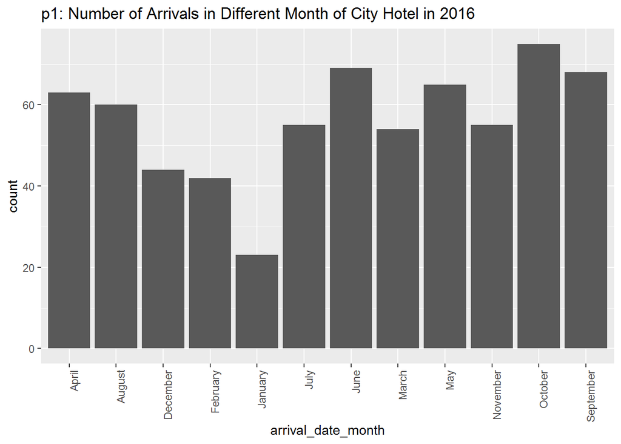

```r
p1 <- dat2 %>% ggplot(aes(arrival_date_month)) +
   geom_bar(aes(x = arrival_date_month)) +
  ggtitle("p1: Number of Arrivals in Different Month of City Hotel in 2016") +
  theme(axis.text.x = element_text(angle = 90, hjust = 1))
p1
```

**According to the *Table 1* and bar plot *p1* above, we can find the duration from September to October is the peak time of travel to City Hotel, the following peak time is the duration from April to June.**

## count the number of arrivals per month of Resort Hotel

```r
dat6 <-dat5 %>%
  dplyr::select(arrival_date_month) %>%
group_by(arrival_date_month) %>%
  mutate(arrivals = n()) %>%
  unique() %>%
  arrange(-arrivals)

#dat6 <-dat5 %>%
# count(arrival_date_month, names = "arrivals", sort = TRUE)

kable(dat6, caption = "Table 3: Number of Arrivals per month of Resort Hotel in 2016") %>%
kable_styling(bootstrap_options = c("striped", "hover"))
```

Table 3: Number of Arrivals per month of Resort Hotel in 2016

| arrival_date_month | arrivals |
| --- | --- |
| October | 35 |
| April | 33 |
| May | 32 |
| March | 31 |
| August | 30 |
| February | 27 |
| September | 27 |
| July | 25 |
| June | 24 |
| November | 24 |
| December | 23 |
| January | 15 |

### use a bar plot to visualize arrivals per month of Resort Hotel

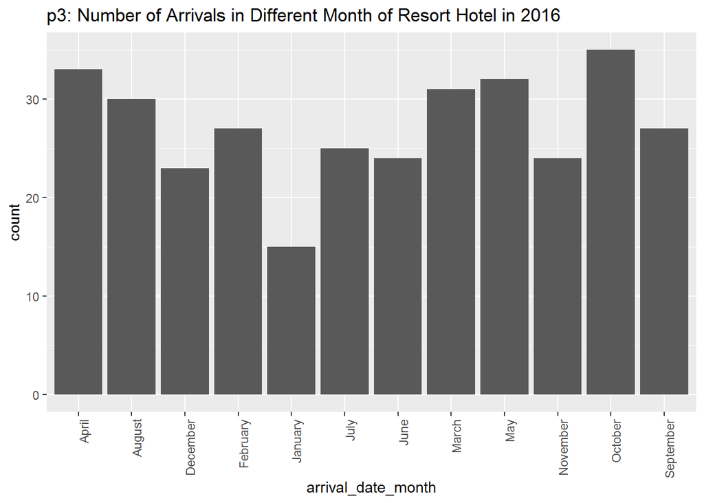

```r
p3 <- dat5 %>% ggplot(aes(arrival_date_month)) +
   geom_bar(aes(x = arrival_date_month)) +
  ggtitle("p3: Number of Arrivals in Different Month of Resort Hotel in 2016") +
  theme(axis.text.x = element_text(angle = 90, hjust = 1))
p3
```

**According to the *Table 3* and bar plot *p3* above, we can find the duration in October is the peak time for travel to Resort Hotel, the following peak time is the duration in from March to May.**

# The average daily rate in 2016

## determine the average daily rate per month of City Hotel

```r
dat4 <- dat2 %>% dplyr::select(arrival_date_month,
                adr)

dat4 <- dat4 %>%
  group_by(arrival_date_month) %>%
  summarise_at(vars(adr),
               list(adr = mean))

kable(dat4, caption = "Table 2: ADR per month in 2016 of City Hotel") %>%
  kable_styling(bootstrap_options = c("striped", "hover"))
```

Table 2: ADR per month in 2016 of City Hotel

| arrival_date_month | adr |
| --- | --- |
| April | 106.05540 |
| August | 131.62283 |
| December | 94.26545 |
| February | 85.79524 |
| January | 69.28130 |
| July | 109.10218 |
| June | 123.34913 |
| March | 91.81889 |
| May | 105.16200 |
| November | 138.43345 |
| October | 106.26387 |
| September | 97.06309 |

### use geom_plot to plot the adr in 12 months of City Hotel

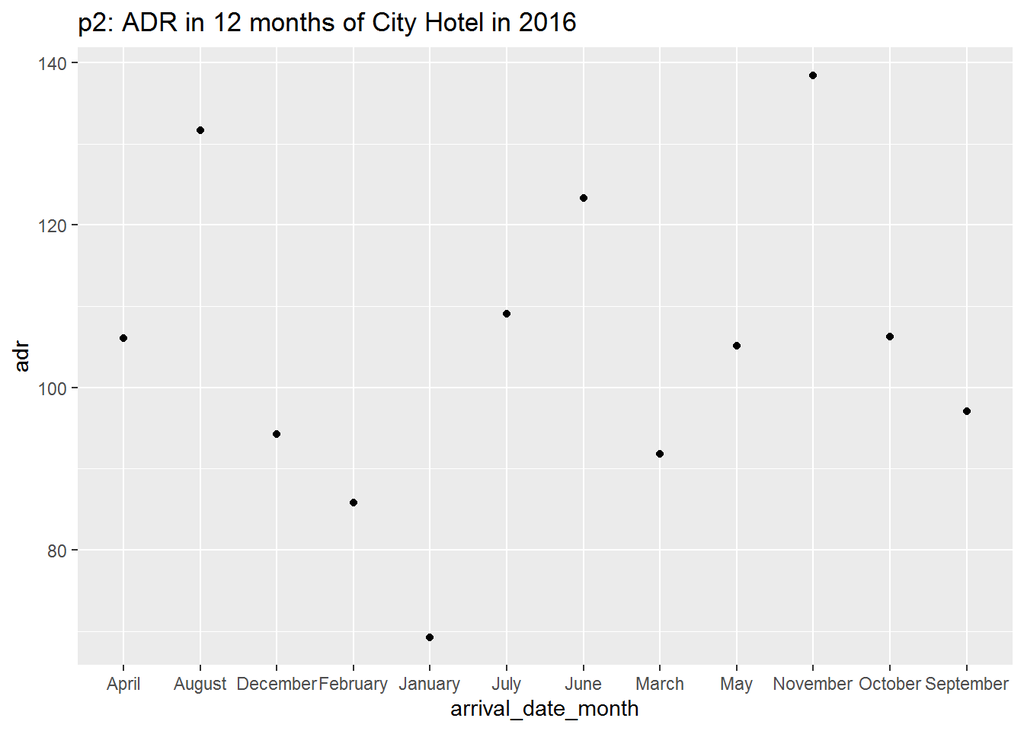

```r
p2 <- dat4 %>% ggplot(aes(x = arrival_date_month, y=adr)) +
  ggtitle("p2: ADR in 12 months of City Hotel in 2016") +
  geom_point()
p2
```

**The *Table 2* is used to calculate the mean ADR for each month in 2016, and we can find the peak and worst ADR of the City Hotel during 2016 from graph *p2*. The highest ADR contributed to November, which means the City Hotel was increasing the money it made from renting out rooms. However, the City Hotel should increase the price per room from January to February.**